# Correlations

Tabea Thies

2022-09-20

# Correlations between variabales

Load necessary packages

```r
library(tidyverse)
library(ggplot2)
```

Load data set

```r
acoustic <- read_csv('../data/acoustics.csv')
artic <- read_csv('../data/articulation.csv')
VAI <- read_csv('../data/formants_VAI.csv')
ratings <- read_csv('../data/listener_ratings.csv')
LEDD <- read_delim('../data/LEDD.csv')
```

Calculate means to reduce tables and to combine them

```r
data_acoustic_avgs <-acoustic %>%
  group_by(speaker, focus_con, med_con) %>%
  summarise(Sylldur = mean(syll.dur, na.rm = T),
            V1dur = mean(V1.dur, na.rm = T))

data_artic_avgs <- artic %>%
  group_by(speaker, focus_con, med_con) %>%
  summarise(age = mean(age, na.rm = T),
            UPDRS = mean(UPDRS_total, na.rm = T),
            axial = mean(UPDRS_axial, na.rm = T),
            rigid = mean(UPDRS_rigidity, na.rm = T),
            brady = mean(UPDRS_brady, na.rm = T),
            PIGD = mean(UPDRS_PIGD, na.rm = T),

            VAS = mean(VAS, na.rm = T),
            BDI = mean(BDI, na.rm = T),
            PANDA = mean(PANDA, na.rm = T),
            MMST = mean(MMST, na.rm = T),

            GAI = mean(GAI_V1, na.rm = T),
            PVEL = mean(pvel_V1_abs, na.rm = T),
            DISP = mean(disp_V1_abs, na.rm = T),
            MMST = mean(MMST, na.rm = T))
```

Combine data frames

```r
VAI$med_con <- recode(VAI$med_con,
                          "CON" = "Control")

data_new1 <- inner_join(data_acoustic_avgs, VAI, by=c("speaker", "med_con", "focus_con"))
data_new2 <- merge(data_new1, data_artic_avgs, by=c("speaker", "med_con", "focus_con", "age", "VAS"))

data_new <- data_new2[ -c(8, 17:26)]
```

Filter data only for broad productions to be able to match it with listener ratings

```r
data_broad <- filter(data_new, focus_con %in% c('broad'))

colnames(ratings)[4] <- "speaker"
colnames(ratings)[3] <- "med_con"

ratings$med_con <- recode(ratings$med_con,
                          "CON" = "Control",
                          "medOFF" = "med-OFF",
                          "medON" = "med-ON",
                          "DBSOFF" = "med-OFF/DBS-OFF",
                          "DBSON" = "med-OFF/DBS-ON")

ratings_avgs <- ratings %>%
  group_by(speaker, med_con) %>%
  summarise(Intell = mean(Intell, na.rm = T),
            Natur = mean(Natural, na.rm = T))

data_broad_new <- merge(data_broad, ratings_avgs, by=c("speaker", "med_con"))
```

Subsets per condition

```r
data_broad_CON <- filter(data_broad_new, med_con %in% c('Control'))
data_broad_medOFF <- filter(data_broad_new, med_con %in% c('med-OFF'))
data_broad_medON <- filter(data_broad_new, med_con %in% c('med-ON'))
data_broad_DBSON <- filter(data_broad_new, med_con %in% c('med-OFF/DBS-ON'))
```

# Statistical analysis: What explains reduced intelligibility?

Acoustic vowel duration ~ Intelligibility

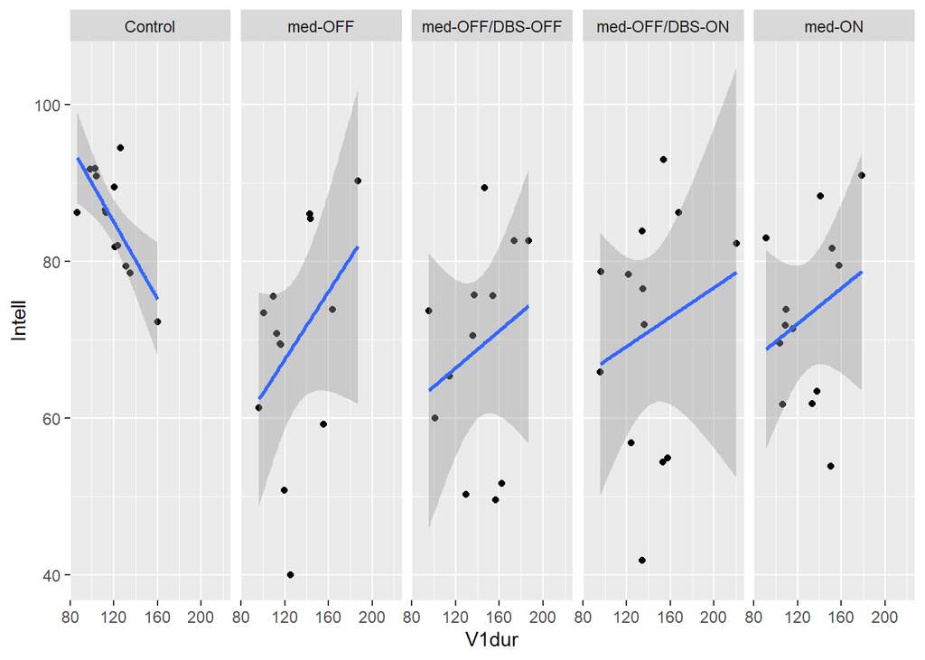

```r
ggplot(data_broad_new, aes(x=V1dur, y=Intell)) +
  geom_point()+
  geom_smooth(method=lm)+
  facet_grid(.~med_con)
```

Calculate correlation coefficient between V1.dur and Intell

```r
## Controls
shapiro.test(data_broad_CON$Intell) # p = 0.6589
```

```
##
##  Shapiro-Wilk normality test
##
## data:  data_broad_CON$Intell
## W = 0.95394, p-value = 0.6589
```

```r
shapiro.test(data_broad_CON$V1dur) # p = 0.9035
```

```
##
##  Shapiro-Wilk normality test
##
## data:  data_broad_CON$V1dur
## W = 0.97079, p-value = 0.9035
```

```r
cor.test(data_broad_CON$Intell, data_broad_CON$V1dur, method = "pearson") ## r(11) = -0.71, p = 0.005784
```

```
##
##  Pearson's product-moment correlation
##
## data:  data_broad_CON$Intell and data_broad_CON$V1dur
## t = -3.414, df = 11, p-value = 0.005784
## alternative hypothesis: true correlation is not equal to 0
## 95 percent confidence interval:
##  -0.9090077 -0.2749326
## sample estimates:
##       cor
## -0.717264
```

```r
## med-OFF
shapiro.test(data_broad_medOFF$Intell) # p = 0.6707
```

```
##
##  Shapiro-Wilk normality test
##
## data:  data_broad_medOFF$Intell
## W = 0.95469, p-value = 0.6707
```

```r
shapiro.test(data_broad_medOFF$V1dur) # p = 0.2911
```

```
##
##  Shapiro-Wilk normality test
##
## data:  data_broad_medOFF$V1dur
## W = 0.92481, p-value = 0.2911
```

```r
cor.test(data_broad_medOFF$Intell, data_broad_medOFF$V1dur, method = "pearson") ## r(11) = 0.41, n.s.
```

```
##
##  Pearson's product-moment correlation
##
## data:  data_broad_medOFF$Intell and data_broad_medOFF$V1dur
## t = 1.4771, df = 11, p-value = 0.1677
## alternative hypothesis: true correlation is not equal to 0
## 95 percent confidence interval:
##  -0.1857940  0.7824326
## sample estimates:
##       cor
## 0.4068394
```

```r
## med-ON
shapiro.test(data_broad_medON$Intell) # p = 0.901
```

```
##
##  Shapiro-Wilk normality test
##
## data:  data_broad_medON$Intell
## W = 0.97057, p-value = 0.901
```

```r
shapiro.test(data_broad_medON$V1dur) # p =  0.6339
```

```
##
##  Shapiro-Wilk normality test
##
## data:  data_broad_medON$V1dur
## W = 0.95232, p-value = 0.6339
```

```r
cor.test(data_broad_medON$Intell, data_broad_medON$V1dur, method = "pearson") ## r(11) = 0.26, n.s.
```

```
##
##  Pearson's product-moment correlation
##
## data:  data_broad_medON$Intell and data_broad_medON$V1dur
## t = 0.90433, df = 11, p-value = 0.3852
## alternative hypothesis: true correlation is not equal to 0
## 95 percent confidence interval:
##  -0.3367304  0.7109933
## sample estimates:
##       cor
## 0.2630616
```

```r
## DBS-ON
shapiro.test(data_broad_DBSON$Intell) # p = 0.5078
```

```
##
##  Shapiro-Wilk normality test
##
## data:  data_broad_DBSON$Intell
## W = 0.94379, p-value = 0.5078
```

```r
shapiro.test(data_broad_DBSON$V1dur) # p =  0.1725
```

```
##
##  Shapiro-Wilk normality test
##
## data:  data_broad_DBSON$V1dur
## W = 0.90806, p-value = 0.1725
```

```r
cor.test(data_broad_DBSON$Intell, data_broad_DBSON$V1dur, method = "pearson") ## r(11) = 0.20, n.s.
```

```
##
##  Pearson's product-moment correlation
##
## data:  data_broad_DBSON$Intell and data_broad_DBSON$V1dur
## t = 0.67306, df = 11, p-value = 0.5148
## alternative hypothesis: true correlation is not equal to 0
## 95 percent confidence interval:
##  -0.3954354  0.6758113
## sample estimates:
##       cor
## 0.1988821
```

VAI ~ Intelligibility

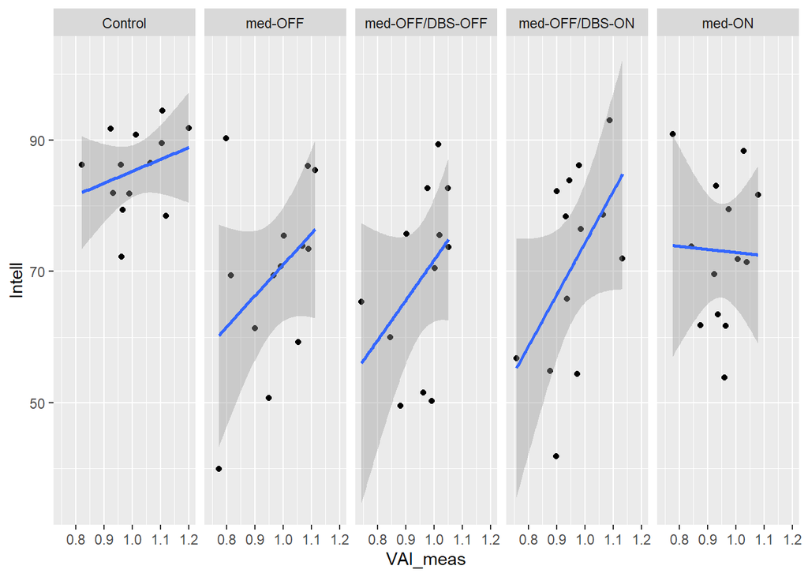

```r
ggplot(data_broad_new, aes(x=VAI_meas, y=Intell)) +
  geom_point()+
  geom_smooth(method=lm)+
  facet_grid(.~med_con)
```

Calculate correlation coefficient between VAI and Intell

```r
## Controls
shapiro.test(data_broad_CON$Intell) # p = 0.6589
```

```
##
##  Shapiro-Wilk normality test
##
## data:  data_broad_CON$Intell
## W = 0.95394, p-value = 0.6589
```

```r
shapiro.test(data_broad_CON$VAI_meas) # p = 0.8711
```

```
##
##  Shapiro-Wilk normality test
##
## data:  data_broad_CON$VAI_meas
## W = 0.96814, p-value = 0.8711
```

```r
cor.test(data_broad_CON$Intell, data_broad_CON$VAI_meas, method = "pearson") ## r(11) = 0.29, n.s.
```

```
##
##  Pearson's product-moment correlation
##
## data:  data_broad_CON$Intell and data_broad_CON$VAI_meas
## t = 1.0037, df = 11, p-value = 0.3371
## alternative hypothesis: true correlation is not equal to 0
## 95 percent confidence interval:
##  -0.3109664  0.7249381
## sample estimates:
##       cor
## 0.2896463
```

```r
## med-OFF
shapiro.test(data_broad_medOFF$Intell) # p = 0.6707
```

```
##
##  Shapiro-Wilk normality test
##
## data:  data_broad_medOFF$Intell
## W = 0.95469, p-value = 0.6707
```

```r
shapiro.test(data_broad_medOFF$VAI_meas) # p = 0.1916
```

```
##
##  Shapiro-Wilk normality test
##
## data:  data_broad_medOFF$VAI_meas
## W = 0.91139, p-value = 0.1916
```

```r
cor.test(data_broad_medOFF$Intell, data_broad_medOFF$VAI_meas, method = "pearson") ## r(11) = 0.39, n.s.
```

```
##
##  Pearson's product-moment correlation
##
## data:  data_broad_medOFF$Intell and data_broad_medOFF$VAI_meas
## t = 1.4034, df = 11, p-value = 0.1881
## alternative hypothesis: true correlation is not equal to 0
## 95 percent confidence interval:
##  -0.2053872  0.7744050
## sample estimates:
##       cor
## 0.3896985
```

```r
## med-ON
shapiro.test(data_broad_medON$Intell) # p = 0.901
```

```
##
##  Shapiro-Wilk normality test
##
## data:  data_broad_medON$Intell
## W = 0.97057, p-value = 0.901
```

```r
shapiro.test(data_broad_medON$VAI_meas) # p = 0.9495
```

```
##
##  Shapiro-Wilk normality test
##
## data:  data_broad_medON$VAI_meas
## W = 0.97543, p-value = 0.9495
```

```r
cor.test(data_broad_medON$Intell, data_broad_medON$VAI_meas, method = "pearson") ## r(11) = -0.04, n.s.
```

```
##
##  Pearson's product-moment correlation
##
## data:  data_broad_medON$Intell and data_broad_medON$VAI_meas
## t = -0.11618, df = 11, p-value = 0.9096
## alternative hypothesis: true correlation is not equal to 0
## 95 percent confidence interval:
##  -0.5749034  0.5261264
## sample estimates:
##         cor
## -0.03500703
```

```r
## DBS-ON
shapiro.test(data_broad_DBSON$Intell) # p = 0.5078
```

```
##
##  Shapiro-Wilk normality test
##
## data:  data_broad_DBSON$Intell
## W = 0.94379, p-value = 0.5078
```

```r
shapiro.test(data_broad_DBSON$VAI_meas) # p = 0.8099
```

```
##
##  Shapiro-Wilk normality test
##
## data:  data_broad_DBSON$VAI_meas
## W = 0.96372, p-value = 0.8099
```

```r
cor.test(data_broad_DBSON$Intell, data_broad_DBSON$VAI_meas, method = "pearson") ## r(11) = 0.51, n.s.
```

```
##
##  Pearson's product-moment correlation
##
## data:  data_broad_DBSON$Intell and data_broad_DBSON$VAI_meas
## t = 1.9533, df = 11, p-value = 0.07668
## alternative hypothesis: true correlation is not equal to 0
## 95 percent confidence interval:
##  -0.06039895  0.82717314
## sample estimates:
##       cor
## 0.5074746
```

Vowel Formant F1 of /a/ ~ Intelligibility

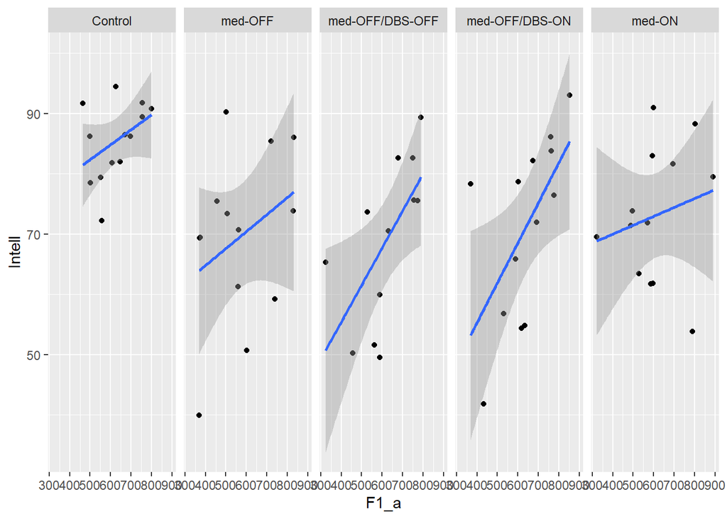

```r
ggplot(data_broad_new, aes(x=F1_a, y=Intell)) +
  geom_point()+
  geom_smooth(method=lm)+
  facet_grid(.~med_con)
```

Calculate correlation coefficient between F1 of /a/ and Intell

```r
## Controls
shapiro.test(data_broad_CON$Intell) # p = 0.6589
```

```
##
##  Shapiro-Wilk normality test
##
## data:  data_broad_CON$Intell
## W = 0.95394, p-value = 0.6589
```

```r
shapiro.test(data_broad_CON$F1_a) # p = 0.738
```

```
##
##  Shapiro-Wilk normality test
##
## data:  data_broad_CON$F1_a
## W = 0.95899, p-value = 0.738
```

```r
cor.test(data_broad_CON$Intell, data_broad_CON$F1_a, method = "pearson") ## r(11) = 0.42, n.s.
```

```
##
##  Pearson's product-moment correlation
##
## data:  data_broad_CON$Intell and data_broad_CON$F1_a
## t = 1.5286, df = 11, p-value = 0.1546
## alternative hypothesis: true correlation is not equal to 0
## 95 percent confidence interval:
##  -0.1721097  0.7878547
## sample estimates:
##       cor
## 0.4185684
```

```r
## med-OFF
shapiro.test(data_broad_medOFF$Intell) # p = 0.6707
```

```
##
##  Shapiro-Wilk normality test
##
## data:  data_broad_medOFF$Intell
## W = 0.95469, p-value = 0.6707
```

```r
shapiro.test(data_broad_medOFF$F1_a) # p = 0.2011
```

```
##
##  Shapiro-Wilk normality test
##
## data:  data_broad_medOFF$F1_a
## W = 0.91294, p-value = 0.2011
```

```r
cor.test(data_broad_medOFF$Intell, data_broad_medOFF$F1_a, method = "pearson") ## r(11) = 0.33, n.s.
```

```
##
##  Pearson's product-moment correlation
##
## data:  data_broad_medOFF$Intell and data_broad_medOFF$F1_a
## t = 1.1495, df = 11, p-value = 0.2747
## alternative hypothesis: true correlation is not equal to 0
## 95 percent confidence interval:
##  -0.2727147  0.7441857
## sample estimates:
##      cor
## 0.327478
```

```r
## med-ON
shapiro.test(data_broad_medON$Intell) # p = 0.901
```

```
##
##  Shapiro-Wilk normality test
##
## data:  data_broad_medON$Intell
## W = 0.97057, p-value = 0.901
```

```r
shapiro.test(data_broad_medON$F1_a) # p =  0.6268
```

```
##
##  Shapiro-Wilk normality test
##
## data:  data_broad_medON$F1_a
## W = 0.95187, p-value = 0.6268
```

```r
cor.test(data_broad_medON$Intell, data_broad_medON$F1_a, method = "pearson") ## r(11) = 0.20, n.s.
```

```
##
##  Pearson's product-moment correlation
##
## data:  data_broad_medON$Intell and data_broad_medON$F1_a
## t = 0.67671, df = 11, p-value = 0.5126
## alternative hypothesis: true correlation is not equal to 0
## 95 percent confidence interval:
##  -0.3945261  0.6763962
## sample estimates:
##       cor
## 0.1999167
```

```r
## DBS-ON
shapiro.test(data_broad_DBSON$Intell) # p = 0.5078
```

```
##
##  Shapiro-Wilk normality test
##
## data:  data_broad_DBSON$Intell
## W = 0.94379, p-value = 0.5078
```

```r
shapiro.test(data_broad_DBSON$F1_a) # p = 0.8548
```

```
##
##  Shapiro-Wilk normality test
##
## data:  data_broad_DBSON$F1_a
## W = 0.9669, p-value = 0.8548
```

```r
cor.test(data_broad_DBSON$Intell, data_broad_DBSON$F1_a, method = "pearson") ## r(11) = 0.61, p = 0.02776
```

```
##
##  Pearson's product-moment correlation
##
## data:  data_broad_DBSON$Intell and data_broad_DBSON$F1_a
## t = 2.5343, df = 11, p-value = 0.02776
## alternative hypothesis: true correlation is not equal to 0
## 95 percent confidence interval:
##  0.08441603 0.86782646
## sample estimates:
##       cor
## 0.6071611
```

Tongue Body Movement Duration ~ Intelligibility

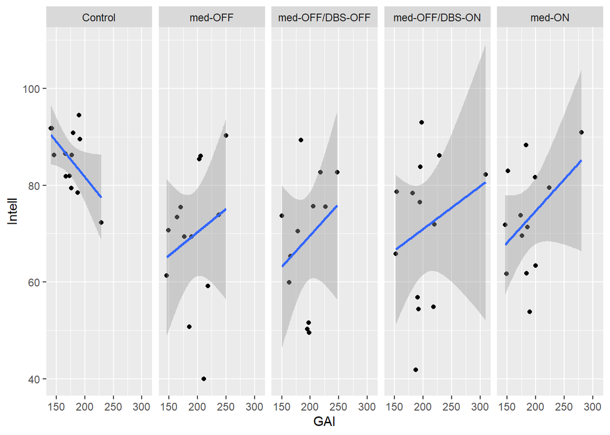

```r
ggplot(data_broad_new, aes(x=GAI, y=Intell)) +
  geom_point()+
  geom_smooth(method=lm)+
  facet_grid(.~med_con)
```

Calculate correlation coefficient between TB duration and Intell

```r
## Controls
shapiro.test(data_broad_CON$Intell) # p = 0.6589
```

```
##
##  Shapiro-Wilk normality test
##
## data:  data_broad_CON$Intell
## W = 0.95394, p-value = 0.6589
```

```r
shapiro.test(data_broad_CON$GAI) # p = 0.2974
```

```
##
##  Shapiro-Wilk normality test
##
## data:  data_broad_CON$GAI
## W = 0.92552, p-value = 0.2974
```

```r
cor.test(data_broad_CON$Intell, data_broad_CON$GAI, method = "pearson") ## r(11) = -0.55, n.s.
```

```
##
##  Pearson's product-moment correlation
##
## data:  data_broad_CON$Intell and data_broad_CON$GAI
## t = -2.1577, df = 11, p-value = 0.05392
## alternative hypothesis: true correlation is not equal to 0
## 95 percent confidence interval:
##  -0.843011909  0.008096653
## sample estimates:
##        cor
## -0.5453214
```

```r
## med-OFF
shapiro.test(data_broad_medOFF$Intell) # p = 0.6707
```

```
##
##  Shapiro-Wilk normality test
##
## data:  data_broad_medOFF$Intell
## W = 0.95469, p-value = 0.6707
```

```r
shapiro.test(data_broad_medOFF$GAI) # p = 0.9314
```

```
##
##  Shapiro-Wilk normality test
##
## data:  data_broad_medOFF$GAI
## W = 0.97342, p-value = 0.9314
```

```r
cor.test(data_broad_medOFF$Intell, data_broad_medOFF$GAI, method = "pearson") ## r(11) = 0.22, n.s.
```

```
##
##  Pearson's product-moment correlation
##
## data:  data_broad_medOFF$Intell and data_broad_medOFF$GAI
## t = 0.73135, df = 11, p-value = 0.4799
## alternative hypothesis: true correlation is not equal to 0
## 95 percent confidence interval:
##  -0.3808333  0.6850435
## sample estimates:
##       cor
## 0.2153369
```

```r
## med-ON
shapiro.test(data_broad_medON$Intell) # p = 0.901
```

```
##
##  Shapiro-Wilk normality test
##
## data:  data_broad_medON$Intell
## W = 0.97057, p-value = 0.901
```

```r
shapiro.test(data_broad_medON$GAI) # p = 0.04856
```

```
##
##  Shapiro-Wilk normality test
##
## data:  data_broad_medON$GAI
## W = 0.86758, p-value = 0.04856
```

```r
cor.test(data_broad_medON$Intell, data_broad_medON$GAI, method = "pearson") ## r(11) = 0.41, n.s.
```

```
##
##  Pearson's product-moment correlation
##
## data:  data_broad_medON$Intell and data_broad_medON$GAI
## t = 1.5077, df = 11, p-value = 0.1598
## alternative hypothesis: true correlation is not equal to 0
## 95 percent confidence interval:
##  -0.1776566  0.7856747
## sample estimates:
##       cor
## 0.4138377
```

```r
## DBS-ON
shapiro.test(data_broad_DBSON$Intell) # p = 0.5078
```

```
##
##  Shapiro-Wilk normality test
##
## data:  data_broad_DBSON$Intell
## W = 0.94379, p-value = 0.5078
```

```r
shapiro.test(data_broad_DBSON$GAI) # p =  0.0162
```

```
##
##  Shapiro-Wilk normality test
##
## data:  data_broad_DBSON$GAI
## W = 0.83078, p-value = 0.0162
```

```r
cor.test(data_broad_DBSON$Intell, data_broad_DBSON$GAI, method = "spearman") ## r(11) = 0.38, n.s.
```

```
##
##  Spearman's rank correlation rho
##
## data:  data_broad_DBSON$Intell and data_broad_DBSON$GAI
## S = 224, p-value = 0.1955
## alternative hypothesis: true rho is not equal to 0
## sample estimates:
##       rho
## 0.3846154
```

Tongue Body Movement Amplitude ~ Intelligibility

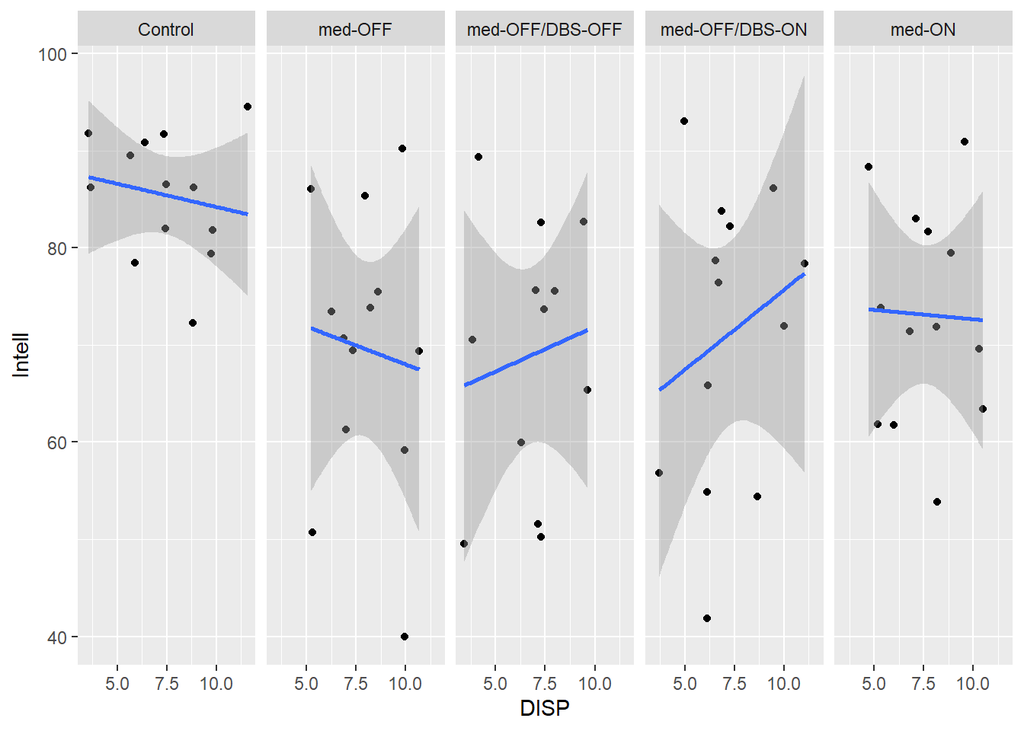

```r
ggplot(data_broad_new, aes(x=DISP, y=Intell)) +
  geom_point()+
  geom_smooth(method=lm)+
  facet_grid(.~med_con)
```

Calculate correlation coefficient between TB amplitude and Intell

```r
## Controls
shapiro.test(data_broad_CON$Intell) # p = 0.6589
```

```
##
##  Shapiro-Wilk normality test
##
## data:  data_broad_CON$Intell
## W = 0.95394, p-value = 0.6589
```

```r
shapiro.test(data_broad_CON$DISP) # p =0.8572
```

```
##
##  Shapiro-Wilk normality test
##
## data:  data_broad_CON$DISP
## W = 0.96708, p-value = 0.8572
```

```r
cor.test(data_broad_CON$Intell, data_broad_CON$DISP, method = "pearson") ## r(11) = -0.18, n.s.
```

```
##
##  Pearson's product-moment correlation
##
## data:  data_broad_CON$Intell and data_broad_CON$DISP
## t = -0.59718, df = 11, p-value = 0.5625
## alternative hypothesis: true correlation is not equal to 0
## 95 percent confidence interval:
##  -0.6634178  0.4142216
## sample estimates:
##        cor
## -0.1772079
```

```r
## med-OFF
shapiro.test(data_broad_medOFF$Intell) # p = 0.6707
```

```
##
##  Shapiro-Wilk normality test
##
## data:  data_broad_medOFF$Intell
## W = 0.95469, p-value = 0.6707
```

```r
shapiro.test(data_broad_medOFF$DISP) # p = 0.533
```

```
##
##  Shapiro-Wilk normality test
##
## data:  data_broad_medOFF$DISP
## W = 0.94558, p-value = 0.533
```

```r
cor.test(data_broad_medOFF$Intell, data_broad_medOFF$DISP, method = "pearson") ## r(11) = -0.10, n.s.
```

```
##
##  Pearson's product-moment correlation
##
## data:  data_broad_medOFF$Intell and data_broad_medOFF$DISP
## t = -0.33092, df = 11, p-value = 0.7469
## alternative hypothesis: true correlation is not equal to 0
## 95 percent confidence interval:
##  -0.6165409  0.4778424
## sample estimates:
##         cor
## -0.09928233
```

```r
## med-ON
shapiro.test(data_broad_medON$Intell) # p = 0.901
```

```
##
##  Shapiro-Wilk normality test
##
## data:  data_broad_medON$Intell
## W = 0.97057, p-value = 0.901
```

```r
shapiro.test(data_broad_medON$DISP) # p = 0.6523
```

```
##
##  Shapiro-Wilk normality test
##
## data:  data_broad_medON$DISP
## W = 0.95351, p-value = 0.6523
```

```r
cor.test(data_broad_medON$Intell, data_broad_medON$DISP, method = "pearson") ## r(11) = -0.03, n.s.
```

```
##
##  Pearson's product-moment correlation
##
## data:  data_broad_medON$Intell and data_broad_medON$DISP
## t = -0.11008, df = 11, p-value = 0.9143
## alternative hypothesis: true correlation is not equal to 0
## 95 percent confidence interval:
##  -0.5736731  0.5274526
## sample estimates:
##        cor
## -0.0331735
```

```r
## DBS-ON
shapiro.test(data_broad_DBSON$Intell) # p = 0.5078
```

```
##
##  Shapiro-Wilk normality test
##
## data:  data_broad_DBSON$Intell
## W = 0.94379, p-value = 0.5078
```

```r
shapiro.test(data_broad_DBSON$DISP) # p = 0.6201
```

```
##
##  Shapiro-Wilk normality test
##
## data:  data_broad_DBSON$DISP
## W = 0.95143, p-value = 0.6201
```

```r
cor.test(data_broad_DBSON$Intell, data_broad_DBSON$DISP, method = "pearson") ## r(11) = 0.22, n.s.
```

```
##
##  Pearson's product-moment correlation
##
## data:  data_broad_DBSON$Intell and data_broad_DBSON$DISP
## t = 0.76116, df = 11, p-value = 0.4626
## alternative hypothesis: true correlation is not equal to 0
## 95 percent confidence interval:
##  -0.3733100  0.6896702
## sample estimates:
##       cor
## 0.2236846
```